# SARFRAZ_HW7

Hussain Sarfraz

10/18/2021

# Homework Name: Working with Strings

## Question 1

To answer this question I created the object **babynames2017** which stores a dataset that containes the names of babies that were born in the year 2017 only. The dataset also has a column that converts the babynames in the column **name** to all lowercase values. I did this so I can make sure all the names I am finding do not have a acidental uppercase letter in it.

- The **filter()** function displays baby names that were only born in 2017
- The **mutate()** function creates the column **name_lowercase** which gets all the names in the **name** column and converts all the names to lowercase characters. I will use this column a lot in the questions below.

```r
babynames2017 <- babynames %>%
  filter(year==2017) %>%
  mutate(name_lowercase = str_to_lower(name))
```

### Question 1: Part A

The vowel **a** is the most common vowel that appears in the first letter of names in 2017. Here are how many times each vowel was in the beginning of each name:

- **a**: 4501 times
- **e**: 1503 times
- **i** : 630 times
- **o**: 409 times
- **u**: 73 times

To find the number of vowels which are in the first letter of names I decided to create 5 columns that count how many times each vowel appears in the beginning of each name in the **babynames2017** dataset.

```r
babynames2017 %>%
  mutate(
    a_vowel = str_count(name_lowercase,"^[a]"),
    e_vowel = str_count(name_lowercase,"^[e]"),
    i_vowel = str_count(name_lowercase,"^[i]"),
    o_vowel = str_count(name_lowercase,"^[o]"),
    u_vowel = str_count(name_lowercase,"^[u]")) %>%
  transmute(
    total_a_vowel = sum(a_vowel),
    total_e_vowel = sum(e_vowel),
    total_i_vowel = sum(i_vowel),
    total_o_vowel = sum(o_vowel),
    total_u_vowel = sum(u_vowel)) %>%
  head(1)
```

```
## # A tibble: 1 x 5
##   total_a_vowel total_e_vowel total_i_vowel total_o_vowel total_u_vowel
##           <int>         <int>         <int>         <int>         <int>
## 1          4501          1503           630           409            73
```

### Question 1: Part B

Many people name their kids that are longer than 5 letters. The results are shown below:

- **Kids who had names less than 5 letters**: 3608
- **Kids who had names more than 5 letters**: 21681

To keep count of how many people name their kids with more than or less than 5 letters I used the **ifelse()** function. So the conditions I set: **str_length(name_lowercase) < 5** and **str_length(name_lowercase) > 5** added a **one** in the column **short5letter** or **long5letter** if the condition was true and added a **zero** if the condition was false.

Then I used the **transmute()** function to only display the sum of the columns **short5letter** and **long5letter**. I did this so I can see if more people name their children names that are shorter or longer than 5 letters. The columns **total_short5letter** and **total_long5letter** display the sum of names that are shorter than five letters or longer than five letters.

I then used **head()** to only display one row of the dataset since I noticed that there were many rows that repeated the same values.

```r
babynames2017 %>%
  mutate(
    short5letter = ifelse((str_length(name_lowercase) < 5),1,0),
    long5letter = ifelse((str_length(name_lowercase) > 5),1,0)) %>%
  transmute(
    total_short5letter = sum(short5letter),
    total_long5letter = sum(long5letter),
    ) %>%
  head(1)
```

```
## # A tibble: 1 x 2
##   total_short5letter total_long5letter
##                <dbl>             <dbl>
## 1               3608             21681
```

### Question 1: Part C

The names that have at least 14 letters are:

1. oluwafunmilayo
2. mariaguadalupe
3. oluwafifehanmi
4. oluwatimilehin
5. oluwatimileyin
6. alexanderjames
7. christianjames
8. christopherjame

I used the function **str_detect()** to see any names/strings that had a commonality with the length that I was specifying. Since **.** matches any character I just wrote **“…………..”** and made sure I used 14 **.** to make sure the names I was getting were at least 14 characters long.

- I used the **filter()** function to only get the names that were at least 14 characters long.

```r
babynames2017 %>%
  filter(
    str_detect(name, "..............")
  )
```

```
## # A tibble: 8 x 6
##    year sex   name                n       prop name_lowercase
##   <dbl> <chr> <chr>           <int>      <dbl> <chr>
## 1  2017 F     Oluwafunmilayo      8 0.00000427 oluwafunmilayo
## 2  2017 F     Mariaguadalupe      6 0.0000032  mariaguadalupe
## 3  2017 F     Oluwafifehanmi      6 0.0000032  oluwafifehanmi
## 4  2017 M     Oluwatimilehin     17 0.00000866 oluwatimilehin
## 5  2017 M     Oluwatimileyin      8 0.00000407 oluwatimileyin
## 6  2017 M     Alexanderjames      6 0.00000306 alexanderjames
## 7  2017 M     Christianjames      5 0.00000255 christianjames
## 8  2017 M     Christopherjame     5 0.00000255 christopherjame
```

### Question 1: Part D

The answer to this question is displayed in my outputs(which is a list) for the code I wrote below.

To answer this question I decided to use the **str_subset()** function since I realized that I can convert the result that I get from a **str_subset()** function to a tibble by just piping a **as_tibble()** function. By using the **as_tibble()** function I made a dataset that contains the list of names that have 2 or more vowels in a row. Doing this allowed me to use the **view()** function that allowed me to see the whole list.

The code **[aeiou]** just tell R to only look for the vowels **a,e,i,o,u** in each name.

I used the **curly brackets** after **[aeiou]** to tell R how many vowels I want to see in a row. For example, **{2,}** means that I am telling R to show me vowels that have 2 or more vowels that are next to each other. **{3,}** means that I am telling R to show me vowels that have 3 or more vowels that are next to each other.

#### **names with 2 or more vowels in a row**

```r
str_subset(babynames2017$name_lowercase,"[aeiou]{2,}") %>%
  as_tibble()
```

```
## # A tibble: 11,557 x 1
##    value
##    <chr>
##  1 olivia
##  2 sophia
##  3 mia
##  4 amelia
##  5 abigail
##  6 sofia
##  7 victoria
##  8 aria
##  9 chloe
## 10 lillian
## # ... with 11,547 more rows
```

Using the **as_tibble()** function I made a dataset that contains the list of names that have 3 or more vowels in a row.

#### **names with 3 or more vowels in a row**

```r
#names with 3 or more vowels in a row
str_subset(babynames2017$name_lowercase,"[aeiou]{3,}") %>%
  as_tibble()
```

```
## # A tibble: 521 x 1
##    value
##    <chr>
##  1 leia
##  2 kaia
##  3 maia
##  4 alaia
##  5 louisa
##  6 louise
##  7 zoie
##  8 saoirse
##  9 amaia
## 10 queen
## # ... with 511 more rows
```

### Question 1: Part E

The names that contain the longest sequential string of consonants are listed below:

1. brynlynn
2. kryslynn

For this question I used trial and error to find the answer.

- I used the **str_view()** function since it just gave my the specific names that matched my commands.
- I wrote **babynames2017$name_lowercase** to let R know which column values I was referring to in the **babynames2017** dataset.
- I then wrote **[^aeiou]** to tell R that I only want to use characters that are not vowels (aks consonants).
- I wrote **{2, }** to tell R to only show me the names that have 2 or more consonants together.
  - **NOTE**: I increased this number every time up till 8 because when I reached 8 I only got 2 names and nothing was displayed at **{9, }** so I decided to use **{8, }**
- I wrote **match=T** to let R know to only give me the values that have a match with my commands (basically the outputs/answers)

```r
# str_view(babynames2017$name_lowercase,"[^aeiou]{2,}", match=T)
# str_view(babynames2017$name_lowercase,"[^aeiou]{3,}", match=T)
# str_view(babynames2017$name_lowercase,"[^aeiou]{4,}", match=T)
# str_view(babynames2017$name_lowercase,"[^aeiou]{5,}", match=T)
# str_view(babynames2017$name_lowercase,"[^aeiou]{6,}", match=T)
# str_view(babynames2017$name_lowercase,"[^aeiou]{7,}", match=T)
str_view(babynames2017$name_lowercase,"[^aeiou]{8,}", match=T)
```

[interactive chart not shown]

## Question 2

Here is the output I got for the 10 most popular names that start with **z** according to the 2017 baby names dataset:

1. zoey
2. zoe
3. zachary
4. zayden
5. zion
6. zane
7. zander
8. zara
9. zayn
10. zuri

Here is the output I got for the 10 most popular names that start with **q** according to the 2017 baby names dataset:

1. quinn (female name)
2. quinn (male name)
3. quentin
4. quinton
5. quincy
6. queen
7. quintin
8. quincy
9. quinten
10. quinley

**NOTE**: The reason why the name **quinn** appears two times in the list is because the dataset separated each name by gender meaning that it showed the popularity of each name by gender. So many females in 2017 were named **quinn** as compared to men who were named **quinn**

To answer this question I created two columns using the **mutate()** function. The column **z_names** would count how many times a name has the letter **z** at the beginning of the name (in this case the value would either be a zero or one because each name has one beginning). The column **percentage** just got the proportion of each name and multiplied the number by 100 to convert the number to a percentage.

I then used the **filter()** function to only have the names that start with the letter **z**. I did this by using the command **z_names==1** since the values in the column **z_names** that have the number one means that those names have the letter **z** in the beginning of the name.

I then used the **arrange()** function to sort the percantage of the names from greatest to least (**desc(percentage)** helped me do the sorting from greatest to least). This would let me see the most popular names.

I then used **head()** to tell R to only dispaly the top 10 names.

**NOTE**: I applied the same logic and explanations to the names that start with the letter **q** which is why I am not writing a explanation for how I found the 10 ten names that start with the letter **q**

#### **10 most popular names that start with z**

```r
babynames2017 %>%
  mutate(z_names = str_count(name_lowercase,"^[z]"),
         percentage = prop*100) %>%
  filter(z_names == 1) %>%
  arrange(desc(percentage)) %>%
  head(10)
```

```
## # A tibble: 10 x 8
##     year sex   name        n     prop name_lowercase z_names percentage
##    <dbl> <chr> <chr>   <int>    <dbl> <chr>            <int>      <dbl>
##  1  2017 F     Zoey     6026 0.00321  zoey                 1     0.321
##  2  2017 F     Zoe      5129 0.00274  zoe                  1     0.274
##  3  2017 M     Zachary  3779 0.00192  zachary              1     0.192
##  4  2017 M     Zayden   2056 0.00105  zayden               1     0.105
##  5  2017 M     Zion     1956 0.000996 zion                 1     0.0996
##  6  2017 M     Zane     1938 0.000987 zane                 1     0.0987
##  7  2017 M     Zander   1546 0.000787 zander               1     0.0787
##  8  2017 F     Zara     1149 0.000613 zara                 1     0.0613
##  9  2017 M     Zayn      988 0.000503 zayn                 1     0.0503
## 10  2017 F     Zuri      847 0.000452 zuri                 1     0.0452
```

#### **10 most popular names that start with q**

```r
babynames2017 %>%
  mutate(q_names = str_count(name_lowercase,"^[q]"),
         percentage = prop*100) %>%
  filter(q_names == 1) %>%
  arrange(desc(percentage)) %>%
  head(10)
```

```
## # A tibble: 10 x 8
##     year sex   name        n      prop name_lowercase q_names percentage
##    <dbl> <chr> <chr>   <int>     <dbl> <chr>            <int>      <dbl>
##  1  2017 F     Quinn    3575 0.00191   quinn                1    0.191
##  2  2017 M     Quinn     892 0.000454  quinn                1    0.0454
##  3  2017 M     Quentin   518 0.000264  quentin              1    0.0264
##  4  2017 M     Quinton   502 0.000256  quinton              1    0.0256
##  5  2017 M     Quincy    431 0.000220  quincy               1    0.0220
##  6  2017 F     Queen     234 0.000125  queen                1    0.0125
##  7  2017 M     Quintin   194 0.0000988 quintin              1    0.00988
##  8  2017 F     Quincy    166 0.0000885 quincy               1    0.00885
##  9  2017 M     Quinten   132 0.0000672 quinten              1    0.00672
## 10  2017 F     Quinley    59 0.0000315 quinley              1    0.00315
```

## Question 3

**8** was the highest number of vowels in a name from the 2017 babynames dataset (referred to as **babynames2017** in code).

**14275** were the number of names that ended in vowels in the 2017 babynames dataset (referred to as **babynames2017** in code).

To find the name that had the highest number of vowels I used the **mutate()** function to create a column(**long_vowel_count**) that counts the amount of vowels in each name. **NOTE**: I used the **name_lowercase** column since all the names are lowercase and I do not have to worry about a mixup with finding names that might have a capital letter..

I then got the values in the column **long_vowel_count** and used the **arrange()** and **desc()** function to sort the values from greatest to least. Doing this helped me see which names had the greatest number of vowels.

I then used the **head()** function to just see the first row since that would be the name that has the highest number of vowels. I got my answer from just looking at the value under the **long_vowel_count** column since that column stores the amount of vowels in each name.

#### **Names from 2017 that have the highest number of vowels**

```r
babynames2017 %>%
  mutate(long_vowel_count = str_count(name_lowercase,"[aeiou]")) %>%
  arrange(desc(long_vowel_count)) %>%
  head(1)
```

```
## # A tibble: 1 x 7
##    year sex   name               n      prop name_lowercase long_vowel_count
##   <dbl> <chr> <chr>          <int>     <dbl> <chr>                     <int>
## 1  2017 F     Mariaguadalupe     6 0.0000032 mariaguadalupe                8
```

To find the number of names that end in vowels I used the **mutate()** function to create a column(**end_vowel**) that counts the amount of names that have a vowel at the end. I wrote **[aeiou]$** to tell R to only look at the letters at the end of each name. This way the count I use would only display two values (one and zero). This is because each name a has one ending and if the letter at the end does not have a vowel then a zero would be displayed.

I then used the **transmute()** function to display the sum of the names that have a vowel at the end. I did this by adding the values stored in the **end_vowel** column and then assigning these values to the column **total_end_vowel**. This means that the column **total_end_vowel** displays the total amount of names that have a vowel at the end.

I then used the **head()** function to just see the first row since the column **total_end_vowel** only displays the total amount of names that have a vowel at the end and this total number (**14275**) was repeating many times in the column **total_end_vowel** so I decided to use **head()** to cut off the repetition.

#### **Names from 2017 that that end in vowels**

```r
babynames2017 %>%
  mutate(end_vowel = str_count(name_lowercase,"[aeiou]$")) %>%
  transmute(total_end_vowel = sum(end_vowel)) %>%
  head(1)
```

```
## # A tibble: 1 x 1
##   total_end_vowel
##             <int>
## 1           14275
```

## Question 4

**NOTE**: I used the **babynames** dataset for this problem instead of the **babynames2017** dataset since the **babynames** dataset included the proportion of the names from all the years and not just 2017. I am doing this question since the question asks me to track the name popularity overtime and not in a specifc year.

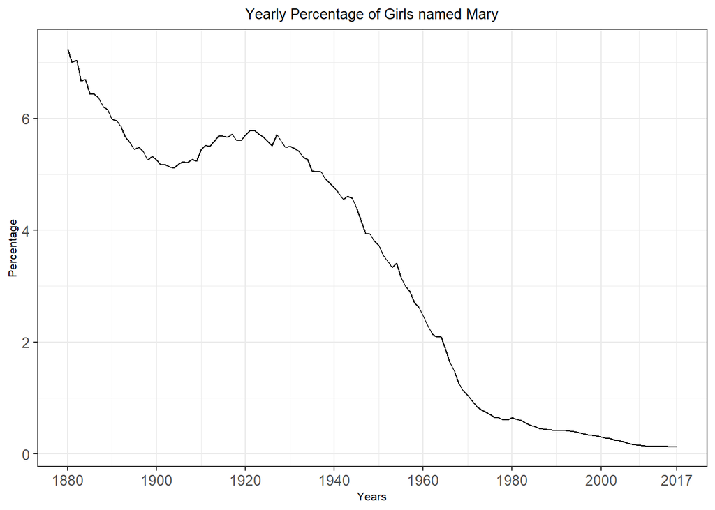

```r
babynames %>%
  mutate(name_lowercase = str_to_lower(name),
         percentage = prop*100) %>%
  filter(name_lowercase == 'mary', sex == 'F') %>%
  ggplot() +
  geom_line( mapping = aes(x=year,y=percentage)) +
  xlab("Years") +
  ylab("Percentage") +
  scale_x_continuous(breaks=c(1880,1900,1920,1940,1960,1980,2000,2017)) +
  ggtitle("Yearly Percentage of Girls named Mary") +
  theme_bw() +
  theme(plot.title = element_text(hjust = 0.5)) +
  theme(axis.text.x = element_text(size = 10),
        axis.text.y = element_text(size = 10),
        axis.title.x = element_text(size = 8),
        axis.title.y = element_text(size = 8),
        plot.title = element_text(size = 10))
```

I noticed that the percentage of girls names Mary decreased as the years went by. There was a dramatic decrease of girls who were named Mary from the years 1930 to 1980. I wonder what led to this decrease and what names started to gain popularity.

### Question 4: Part A

The most popular girls name in 2017 is **Emma**.

To find the most popular girls name in 2017 I decided to use the **mutate()** function to change the name proportions to percentages. I then used the **filter()** function to only see the names of people who were female. From here I used the **arrange()** and **desc()** functions to display the percentage of the most popular female names in 2017 from greatest to least.

**NOTE**: I used the dataset **babynames2017** here since I wanted to specifically see names in 2017 and the dataset **babynames2017** only displays names in 2017. I use the **babynames** dataset when graphing

```r
babynames2017 %>%
  mutate(percentage = prop*100) %>%
  filter(sex == 'F') %>%
  arrange(desc(percentage)) %>%
  head(1)
```

```
## # A tibble: 1 x 7
##    year sex   name      n   prop name_lowercase percentage
##   <dbl> <chr> <chr> <int>  <dbl> <chr>               <dbl>
## 1  2017 F     Emma  19738 0.0105 emma                 1.05
```

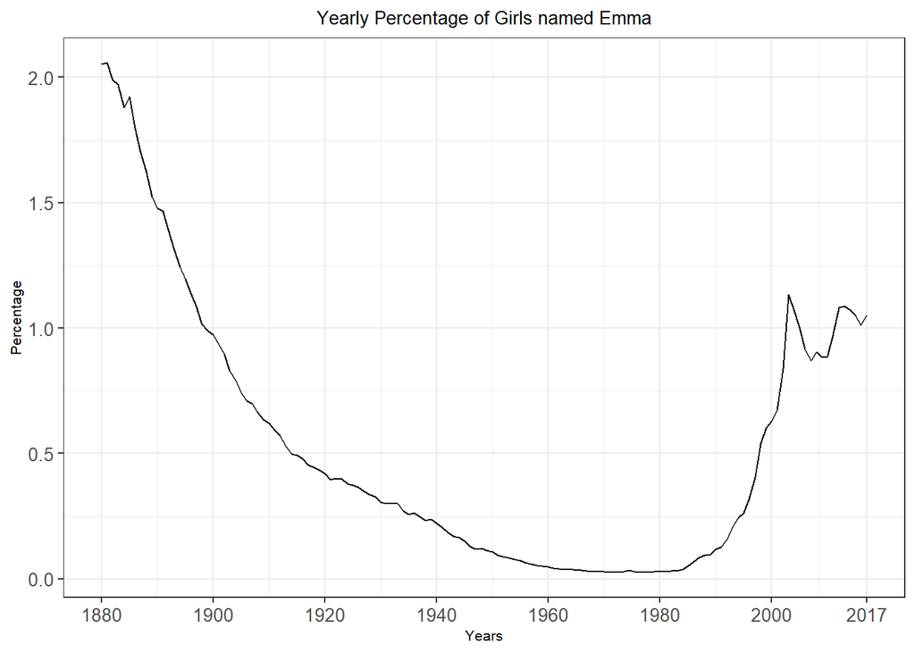

```r
babynames %>%
  mutate(name_lowercase = str_to_lower(name),
         percentage = prop*100) %>%
  filter(name_lowercase == 'emma', sex == 'F') %>%
  ggplot() +
  geom_line( mapping = aes(x=year,y=percentage)) +
  xlab("Years") +
  ylab("Percentage") +
  scale_x_continuous(breaks=c(1880,1900,1920,1940,1960,1980,2000,2017)) +
  ggtitle("Yearly Percentage of Girls named Emma") +
  theme_bw() +
  theme(plot.title = element_text(hjust = 0.5)) +
  theme(axis.text.x = element_text(size = 10),
        axis.text.y = element_text(size = 10),
        axis.title.x = element_text(size = 8),
        axis.title.y = element_text(size = 8),
        plot.title = element_text(size = 10))
```

I noticed that the name Emma decreased in popularity around the time 1890-1980 but started to increase around 1980-2005 (approximately). After comparing this graph with the previous one I can see that names like Emma are becoming more popular as compared to names like Mary.

## Question 5

To answer this question I used the **filter()** function to only see babies who were named **Peyton**. In my plot, I wrote **color=sex** so R can do the grouping of the male and female variables (**M** and **F**) in the **sex** column of the **babynames** dataset. When the grouping is done R would then display two lines in the graph (one represents males who are names Peyton and one represents females who were named Peyton).

I then used **scale_color_manual()** to assign a specific color to the lines and to sustomize the legend and line titles. I use **c()** when there are more than one variables/lines in the legend and this lets R know which line I am referring too.

[figure not shown]

```r
babynames %>%
  mutate(name_lowercase = str_to_lower(name)) %>%
  filter(name_lowercase == 'peyton') %>%
  ggplot() +
  geom_line( mapping = aes(x=year,y=prop, color=sex)) +
  xlab("Years") +
  ylab("Percentage") +
  scale_x_continuous(breaks=c(1880,1900,1920,1940,1960,1980,2000,2017)) +
  ggtitle("Yearly Percentage of Girls named Peyton") +
  theme_bw() +
  theme(plot.title = element_text(hjust = 0.5)) +
  theme(axis.text.x = element_text(size = 10),
        axis.text.y = element_text(size = 10),
        axis.title.x = element_text(size = 8),
        axis.title.y = element_text(size = 8),
        plot.title = element_text(size = 10)) +
  scale_color_manual(values = c('red', 'blue'),
    name="Line Legend",
                       labels=c(
                         "F" = 'Females',
                         "M" = 'Male'))
```